# London Crystals Moissanite - HW2 Code

STA 6704 Assignment 2 Student Code

# Introduction

This R Markdown file provides the code needed for the computational parts of Assignment 2. Run the chunks below with `Moissanite.csv` in your working directory, then use the output to answer the questions in the Word document.

The dataset `Moissanite.csv` contains a modified version of the original diamonds dataset. The response variable is `price`, and the predictors are described in the assignment data dictionary. In the posted version of `Moissanite.csv`, the original clarity levels have already been collapsed into `I.SI`, `VS`, `VV`, and `IF`. The setup chunk below also includes a compatibility check so that the code can safely handle either the collapsed clarity labels or the original diamond clarity labels.

If any required package is missing on your computer, uncomment and run the installation line below once in the R console, then run this R Markdown file again.

```r
# install.packages(c("caret", "MASS", "glmnet"))
```

# Preparing the Data

Run this chunk first. It loads the data, orders the categorical variables, checks that the expected categories were read correctly, and creates the same train/test split for everyone. Do not change the seed, train/test split, or lambda grid.

```r
library(caret)
library(MASS)
library(glmnet)

moissanite <- read.csv("Moissanite.csv", stringsAsFactors = FALSE)

required_columns <- c("carat", "cut", "color", "clarity", "depth", "table", "price", "x", "y", "z")
missing_columns <- setdiff(required_columns, names(moissanite))
if (length(missing_columns) > 0) {
  stop(paste("Moissanite.csv is missing these required columns:", paste(missing_columns, collapse = ", ")))
}

# Keep only the variables used in this assignment, in a consistent order.
moissanite <- moissanite[, required_columns]

# Remove accidental leading/trailing spaces in categorical variables.
moissanite$cut <- trimws(as.character(moissanite$cut))
moissanite$color <- trimws(as.character(moissanite$color))
moissanite$clarity <- trimws(as.character(moissanite$clarity))

# Collapse clarity if the CSV still uses the original diamonds labels.
moissanite$clarity <- ifelse(moissanite$clarity %in% c("SI1", "SI2", "I1"), "I.SI", moissanite$clarity)
moissanite$clarity <- ifelse(moissanite$clarity %in% c("VS1", "VS2"), "VS", moissanite$clarity)
moissanite$clarity <- ifelse(moissanite$clarity %in% c("VVS1", "VVS2"), "VV", moissanite$clarity)

# Use the lower-quality category as the baseline for ordered quality variables.
moissanite$cut <- factor(moissanite$cut,
                         levels = c("Fair", "Good", "Very Good", "Premium", "Ideal"))

moissanite$color <- factor(moissanite$color,
                           levels = c("J", "I", "H", "G", "F", "E", "D"))

moissanite$clarity <- factor(moissanite$clarity,
                             levels = c("I.SI", "VS", "VV", "IF"))

# Sanity checks. These stop the file early if the CSV uses unexpected labels.
if (anyNA(moissanite$cut)) {
  stop("Some cut values were not recognized. Check that Moissanite.csv uses Fair, Good, Very Good, Premium, and Ideal.")
}

if (anyNA(moissanite$color)) {
  stop("Some color values were not recognized. Check that Moissanite.csv uses D, E, F, G, H, I, and J.")
}

if (anyNA(moissanite$clarity)) {
  stop("Some clarity values were not recognized. Expected collapsed labels I.SI, VS, VV, IF, or original labels SI1, SI2, I1, VS1, VS2, VVS1, VVS2, IF.")
}

if (any(!is.finite(moissanite$price)) || any(moissanite$price <= 0)) {
  stop("The Gamma GLM requires all price values to be positive and finite.")
}

# The Gamma GLM in Exercise 2.7 is sensitive to invalid physical measurements.
# A small number of rows in the diamonds/moissanite-style data have x, y, or z
# recorded as 0, which is not physically meaningful for length/width/depth and
# can cause glm() with Gamma(log) to diverge. Remove those rows before splitting.
invalid_dimensions <- !is.finite(moissanite$x) | !is.finite(moissanite$y) | !is.finite(moissanite$z) |
  moissanite$x <= 0 | moissanite$y <= 0 | moissanite$z <= 0

if (any(invalid_dimensions)) {
  message(sum(invalid_dimensions), " rows with non-positive or non-finite x/y/z were removed before model fitting.")
  moissanite <- moissanite[!invalid_dimensions, ]
}

set.seed(161)
ind <- createDataPartition(moissanite$price,
                           list = FALSE, p = 0.7)

train <- moissanite[ind, ]
test  <- moissanite[-ind, ]

rmse <- function(actual, predicted) {
  sqrt(mean((actual - predicted)^2))
}
```

# Exercise 2.1: Full MLR Model

Run the following code to fit the full multiple linear regression model and inspect the coefficient table.

```r
mlr.full <- lm(price ~ ., data = train)
summary(mlr.full)
```

```
##
## Call:
## lm(formula = price ~ ., data = train)
##
## Residuals:
##      Min       1Q   Median       3Q      Max
## -23435.4   -605.1   -162.1    455.4  10829.0
##
## Coefficients:
##               Estimate Std. Error t value Pr(>|t|)
## (Intercept)   3159.113    523.254   6.037 1.58e-09 ***
## carat        11108.291     66.789 166.318  < 2e-16 ***
## cutGood       1051.688     43.288  24.295  < 2e-16 ***
## cutVery Good  1231.450     41.482  29.687  < 2e-16 ***
## cutPremium    1217.719     41.502  29.341  < 2e-16 ***
## cutIdeal      1306.351     43.033  30.357  < 2e-16 ***
## colorI         881.489     33.977  25.944  < 2e-16 ***
## colorH        1334.413     32.137  41.523  < 2e-16 ***
## colorG        1815.841     31.362  57.899  < 2e-16 ***
## colorF        2001.317     32.012  62.518  < 2e-16 ***
## colorE        2064.926     32.074  64.379  < 2e-16 ***
## colorD        2264.136     33.674  67.237  < 2e-16 ***
## clarityVS     1172.910     14.508  80.848  < 2e-16 ***
## clarityVV     1708.114     19.839  86.097  < 2e-16 ***
## clarityIF     2042.627     37.261  54.819  < 2e-16 ***
## depth          -67.349      5.787 -11.638  < 2e-16 ***
## table          -27.840      3.747  -7.430 1.11e-13 ***
## x            -1037.434     42.325 -24.511  < 2e-16 ***
## y               36.866     23.704   1.555   0.1199
## z              -78.923     41.169  -1.917   0.0552 .
## ---
## Signif. codes:  0 '***' 0.001 '**' 0.01 '*' 0.05 '.' 0.1 ' ' 1
##
## Residual standard error: 1219 on 37726 degrees of freedom
## Multiple R-squared:  0.9058, Adjusted R-squared:  0.9058
## F-statistic: 1.91e+04 on 19 and 37726 DF,  p-value: < 2.2e-16
```

The following code lists coefficient terms with p-values greater than 0.05. For categorical predictors, this output refers to individual factor-level coefficients, not necessarily the entire categorical variable.

```r
full_coef_table <- coef(summary(mlr.full))
insignificant_terms <- full_coef_table[full_coef_table[, "Pr(>|t|)"] > 0.05, , drop = FALSE]

insignificant_terms_table <- data.frame(
  Term = rownames(insignificant_terms),
  Estimate = insignificant_terms[, "Estimate"],
  Std_Error = insignificant_terms[, "Std. Error"],
  t_value = insignificant_terms[, "t value"],
  p_value = insignificant_terms[, "Pr(>|t|)"],
  row.names = NULL
)

insignificant_terms_table
```

| Term | Estimate | Std_Error | t_value | p_value |
| --- | --- | --- | --- | --- |
| y | 36.86553 | 23.70392 | 1.555250 | 0.11989488 |
| z | -78.92342 | 41.16926 | -1.917048 | 0.05523944 |

# Exercise 2.2: Stepwise Selection

The code below runs backward stepwise selection from the full model using AIC. It also runs the analogous BIC version so that you can compare and justify your recommendation.

```r
mlr.mod0 <- lm(price ~ 1, data = train)

mlr.step.aic <- stepAIC(mlr.full,
                        k = 2,
                        direction = "backward",
                        scope = list(upper = mlr.full, lower = mlr.mod0),
                        trace = FALSE)

mlr.step.bic <- stepAIC(mlr.full,
                        k = log(nrow(train)),
                        direction = "backward",
                        scope = list(upper = mlr.full, lower = mlr.mod0),
                        trace = FALSE)
```

Use the following output to report the final resulting MLRs and identify eliminated variables.

```r
formula(mlr.step.aic)
```

```
## price ~ carat + cut + color + clarity + depth + table + x + y +
##     z
```

```r
formula(mlr.step.bic)
```

```
## price ~ carat + cut + color + clarity + depth + table + x
```

```r
full_terms <- attr(terms(mlr.full), "term.labels")
aic_terms  <- attr(terms(mlr.step.aic), "term.labels")
bic_terms  <- attr(terms(mlr.step.bic), "term.labels")

cat("Variables eliminated by AIC stepwise selection:\n")
```

```
## Variables eliminated by AIC stepwise selection:
```

```r
setdiff(full_terms, aic_terms)
```

```
## character(0)
```

```r
cat("Variables eliminated by BIC stepwise selection:\n")
```

```
## Variables eliminated by BIC stepwise selection:
```

```r
setdiff(full_terms, bic_terms)
```

```
## [1] "y" "z"
```

```r
summary(mlr.step.aic)
```

```
##
## Call:
## lm(formula = price ~ carat + cut + color + clarity + depth +
##     table + x + y + z, data = train)
##
## Residuals:
##      Min       1Q   Median       3Q      Max
## -23435.4   -605.1   -162.1    455.4  10829.0
##
## Coefficients:
##               Estimate Std. Error t value Pr(>|t|)
## (Intercept)   3159.113    523.254   6.037 1.58e-09 ***
## carat        11108.291     66.789 166.318  < 2e-16 ***
## cutGood       1051.688     43.288  24.295  < 2e-16 ***
## cutVery Good  1231.450     41.482  29.687  < 2e-16 ***
## cutPremium    1217.719     41.502  29.341  < 2e-16 ***
## cutIdeal      1306.351     43.033  30.357  < 2e-16 ***
## colorI         881.489     33.977  25.944  < 2e-16 ***
## colorH        1334.413     32.137  41.523  < 2e-16 ***
## colorG        1815.841     31.362  57.899  < 2e-16 ***
## colorF        2001.317     32.012  62.518  < 2e-16 ***
## colorE        2064.926     32.074  64.379  < 2e-16 ***
## colorD        2264.136     33.674  67.237  < 2e-16 ***
## clarityVS     1172.910     14.508  80.848  < 2e-16 ***
## clarityVV     1708.114     19.839  86.097  < 2e-16 ***
## clarityIF     2042.627     37.261  54.819  < 2e-16 ***
## depth          -67.349      5.787 -11.638  < 2e-16 ***
## table          -27.840      3.747  -7.430 1.11e-13 ***
## x            -1037.434     42.325 -24.511  < 2e-16 ***
## y               36.866     23.704   1.555   0.1199
## z              -78.923     41.169  -1.917   0.0552 .
## ---
## Signif. codes:  0 '***' 0.001 '**' 0.01 '*' 0.05 '.' 0.1 ' ' 1
##
## Residual standard error: 1219 on 37726 degrees of freedom
## Multiple R-squared:  0.9058, Adjusted R-squared:  0.9058
## F-statistic: 1.91e+04 on 19 and 37726 DF,  p-value: < 2.2e-16
```

```r
summary(mlr.step.bic)
```

```
##
## Call:
## lm(formula = price ~ carat + cut + color + clarity + depth +
##     table + x, data = train)
##
## Residuals:
##      Min       1Q   Median       3Q      Max
## -23450.6   -605.2   -162.3    455.1  10829.1
##
## Coefficients:
##               Estimate Std. Error t value Pr(>|t|)
## (Intercept)   3450.328    503.981   6.846  7.7e-12 ***
## carat        11108.006     66.756 166.398  < 2e-16 ***
## cutGood       1053.752     43.264  24.356  < 2e-16 ***
## cutVery Good  1233.116     41.447  29.752  < 2e-16 ***
## cutPremium    1218.956     41.501  29.372  < 2e-16 ***
## cutIdeal      1308.087     43.021  30.406  < 2e-16 ***
## colorI         881.705     33.978  25.949  < 2e-16 ***
## colorH        1334.700     32.138  41.531  < 2e-16 ***
## colorG        1815.905     31.364  57.898  < 2e-16 ***
## colorF        2001.437     32.013  62.519  < 2e-16 ***
## colorE        2064.712     32.075  64.370  < 2e-16 ***
## colorD        2264.230     33.675  67.237  < 2e-16 ***
## clarityVS     1172.724     14.508  80.834  < 2e-16 ***
## clarityVV     1708.113     19.840  86.095  < 2e-16 ***
## clarityIF     2042.609     37.262  54.818  < 2e-16 ***
## depth          -72.105      5.283 -13.649  < 2e-16 ***
## table          -27.838      3.746  -7.432  1.1e-13 ***
## x            -1049.121     28.308 -37.060  < 2e-16 ***
## ---
## Signif. codes:  0 '***' 0.001 '**' 0.01 '*' 0.05 '.' 0.1 ' ' 1
##
## Residual standard error: 1219 on 37728 degrees of freedom
## Multiple R-squared:  0.9058, Adjusted R-squared:  0.9058
## F-statistic: 2.135e+04 on 17 and 37728 DF,  p-value: < 2.2e-16
```

# Exercise 2.3: Ridge Regression

For ridge regression, the code uses `alpha = 0`. The lambda grid is fixed as instructed in the assignment and should not be changed.

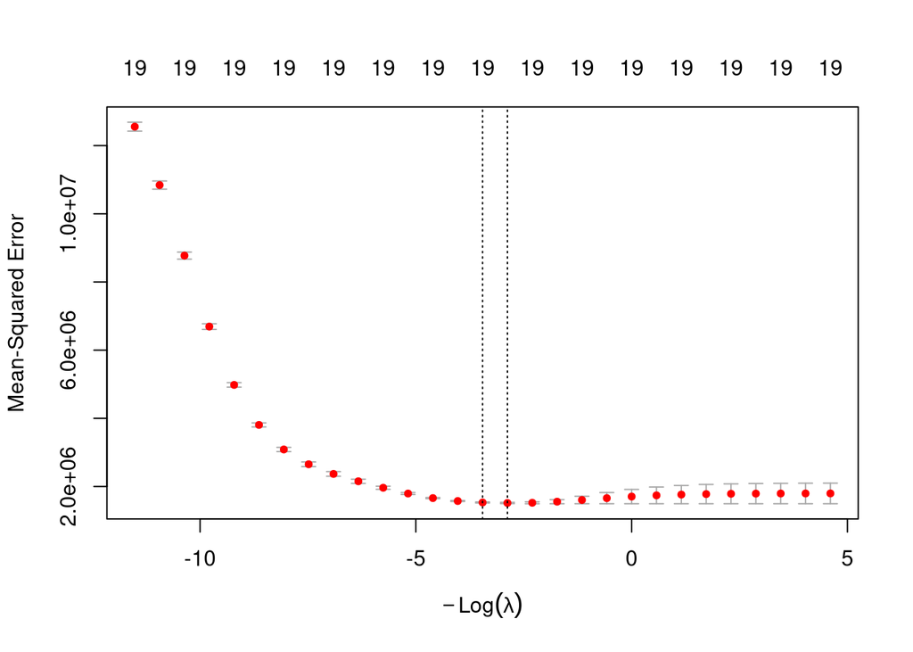

```r
trainXmat <- model.matrix(price ~ ., data = train)
testXmat  <- model.matrix(price ~ ., data = test)

set.seed(161)
mlr.ridge <- cv.glmnet(x = trainXmat[, -1],
                       y = train$price,
                       family = "gaussian",
                       alpha = 0,
                       lambda = 10^(seq(-2, 5, by = 0.25)))

plot(mlr.ridge)
```

```r
mlr.ridge.mod <- glmnet(x = trainXmat[, -1],
                        y = train$price,
                        family = "gaussian",
                        lambda = mlr.ridge$lambda.1se,
                        alpha = 0)
```

The following values are needed for the ridge questions.

```r
cat("Ridge alpha:\n")
```

```
## Ridge alpha:
```

```r
0
```

```
## [1] 0
```

```r
cat("Ridge lambda.min:\n")
```

```
## Ridge lambda.min:
```

```r
mlr.ridge$lambda.min
```

```
## [1] 17.78279
```

```r
cat("Ridge lambda.1se:\n")
```

```
## Ridge lambda.1se:
```

```r
mlr.ridge$lambda.1se
```

```
## [1] 31.62278
```

```r
cat("Ridge coefficients at lambda.1se:\n")
```

```
## Ridge coefficients at lambda.1se:
```

```r
coef(mlr.ridge.mod)
```

```
## 20 x 1 sparse Matrix of class "dgCMatrix"
##                      s0
## (Intercept)  -875.02841
## carat        9122.01063
## cutGood       833.21198
## cutVery Good 1018.77881
## cutPremium   1001.29128
## cutIdeal     1078.03927
## colorI        666.84497
## colorH       1082.34372
## colorG       1532.10988
## colorF       1699.35658
## colorE       1779.04085
## colorD       1968.51143
## clarityVS    1161.63321
## clarityVV    1743.05579
## clarityIF    2087.46108
## depth         -41.78608
## table         -30.05560
## x            -221.98136
## y              27.75740
## z             -73.61424
```

# Exercise 2.4: Lasso Regression

For lasso regression, the code uses `alpha = 1`. The lambda grid is fixed as instructed in the assignment and should not be changed.

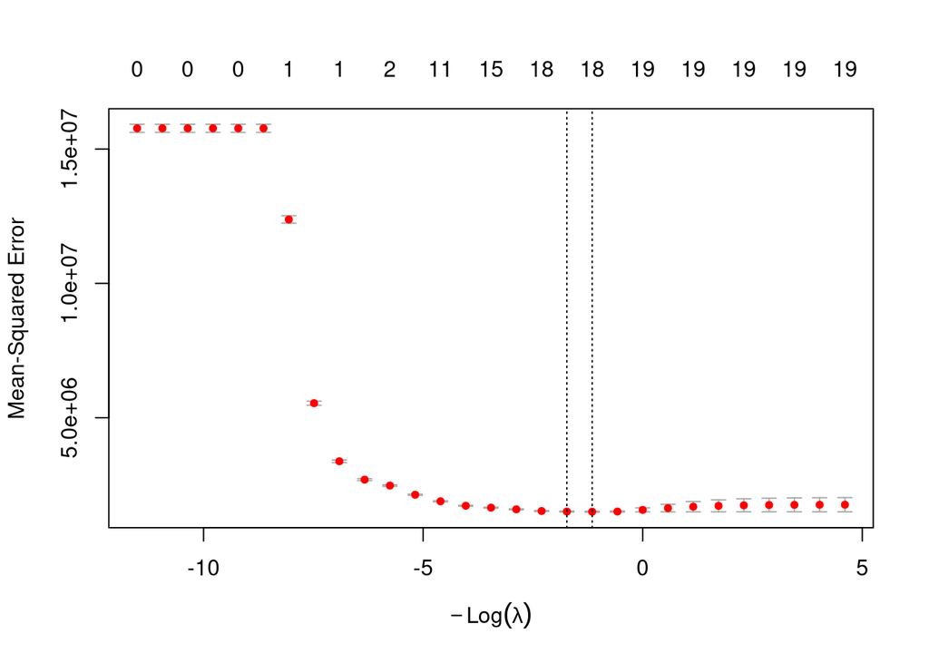

```r
set.seed(161)
mlr.lasso <- cv.glmnet(x = trainXmat[, -1],
                       y = train$price,
                       family = "gaussian",
                       alpha = 1,
                       lambda = 10^(seq(-2, 5, by = 0.25)))

plot(mlr.lasso)
```

```r
mlr.lasso.mod <- glmnet(x = trainXmat[, -1],
                        y = train$price,
                        family = "gaussian",
                        lambda = mlr.lasso$lambda.1se,
                        alpha = 1)
```

Use the following coefficient output to compare ridge and lasso. Ridge typically shrinks coefficients toward zero but does not set them exactly equal to zero, while lasso can set some coefficients exactly equal to zero.

```r
cat("Lasso alpha:\n")
```

```
## Lasso alpha:
```

```r
1
```

```
## [1] 1
```

```r
cat("Ridge coefficients at lambda.1se:\n")
```

```
## Ridge coefficients at lambda.1se:
```

```r
coef(mlr.ridge.mod)
```

```
## 20 x 1 sparse Matrix of class "dgCMatrix"
##                      s0
## (Intercept)  -875.02841
## carat        9122.01063
## cutGood       833.21198
## cutVery Good 1018.77881
## cutPremium   1001.29128
## cutIdeal     1078.03927
## colorI        666.84497
## colorH       1082.34372
## colorG       1532.10988
## colorF       1699.35658
## colorE       1779.04085
## colorD       1968.51143
## clarityVS    1161.63321
## clarityVV    1743.05579
## clarityIF    2087.46108
## depth         -41.78608
## table         -30.05560
## x            -221.98136
## y              27.75740
## z             -73.61424
```

```r
cat("Lasso coefficients at lambda.1se:\n")
```

```
## Lasso coefficients at lambda.1se:
```

```r
coef(mlr.lasso.mod)
```

```
## 20 x 1 sparse Matrix of class "dgCMatrix"
##                       s0
## (Intercept)   2983.87575
## carat        10469.15513
## cutGood        703.86992
## cutVery Good   889.63716
## cutPremium     872.27975
## cutIdeal       962.81123
## colorI         619.09689
## colorH        1061.23470
## colorG        1537.65274
## colorF        1713.03447
## colorE        1782.51932
## colorD        1974.57665
## clarityVS     1153.66987
## clarityVV     1705.07799
## clarityIF     2023.91487
## depth          -68.01892
## table          -29.84838
## x             -770.40692
## y                .
## z              -42.11046
```

```r
cat("Nonzero lasso coefficients at lambda.1se:\n")
```

```
## Nonzero lasso coefficients at lambda.1se:
```

```r
coef_lasso <- as.matrix(coef(mlr.lasso.mod))
coef_lasso[coef_lasso[, 1] != 0, , drop = FALSE]
```

```
##                       s0
## (Intercept)   2983.87575
## carat        10469.15513
## cutGood        703.86992
## cutVery Good   889.63716
## cutPremium     872.27975
## cutIdeal       962.81123
## colorI         619.09689
## colorH        1061.23470
## colorG        1537.65274
## colorF        1713.03447
## colorE        1782.51932
## colorD        1974.57665
## clarityVS     1153.66987
## clarityVV     1705.07799
## clarityIF     2023.91487
## depth          -68.01892
## table          -29.84838
## x             -770.40692
## z              -42.11046
```

# Exercise 2.5: RMSE Comparison of MLR, Stepwise, Ridge, and Lasso Models

The code below computes training and test RMSEs for the full MLR, AIC stepwise MLR, BIC stepwise MLR, ridge, and lasso models. For a prediction-focused recommendation, focus primarily on test RMSE. Training RMSE is still useful for discussing in-sample fit and possible overfitting.

```r
mlr.full.train.preds <- predict(mlr.full, newdata = train)
mlr.full.test.preds  <- predict(mlr.full, newdata = test)

mlr.step.aic.train.preds <- predict(mlr.step.aic, newdata = train)
mlr.step.aic.test.preds  <- predict(mlr.step.aic, newdata = test)

mlr.step.bic.train.preds <- predict(mlr.step.bic, newdata = train)
mlr.step.bic.test.preds  <- predict(mlr.step.bic, newdata = test)

mlr.ridge.train.preds <- as.numeric(predict(mlr.ridge.mod, newx = trainXmat[, -1]))
mlr.ridge.test.preds  <- as.numeric(predict(mlr.ridge.mod, newx = testXmat[, -1]))

mlr.lasso.train.preds <- as.numeric(predict(mlr.lasso.mod, newx = trainXmat[, -1]))
mlr.lasso.test.preds  <- as.numeric(predict(mlr.lasso.mod, newx = testXmat[, -1]))

model_rmse_table <- data.frame(
  Model = c("Full MLR", "Stepwise MLR - AIC", "Stepwise MLR - BIC", "Ridge", "Lasso"),
  Training_RMSE = c(
    rmse(train$price, mlr.full.train.preds),
    rmse(train$price, mlr.step.aic.train.preds),
    rmse(train$price, mlr.step.bic.train.preds),
    rmse(train$price, mlr.ridge.train.preds),
    rmse(train$price, mlr.lasso.train.preds)
  ),
  Test_RMSE = c(
    rmse(test$price, mlr.full.test.preds),
    rmse(test$price, mlr.step.aic.test.preds),
    rmse(test$price, mlr.step.bic.test.preds),
    rmse(test$price, mlr.ridge.test.preds),
    rmse(test$price, mlr.lasso.test.preds)
  )
)

model_rmse_table
```

| Model | Training_RMSE | Test_RMSE |
| --- | --- | --- |
| Full MLR | 1218.690 | 1240.105 |
| Stepwise MLR - AIC | 1218.690 | 1240.105 |
| Stepwise MLR - BIC | 1218.778 | 1240.265 |
| Ridge | 1234.234 | 1254.838 |
| Lasso | 1222.791 | 1242.361 |

# Exercise 2.6: Numerical Summary and Histogram of Price

Use the following code to summarize and visualize the price distribution.

```r
summary(moissanite$price)
```

```
##    Min. 1st Qu.  Median    Mean 3rd Qu.    Max.
##     326     949    2401    3931    5323   18823
```

```r
sd(moissanite$price)
```

```
## [1] 3987.28
```

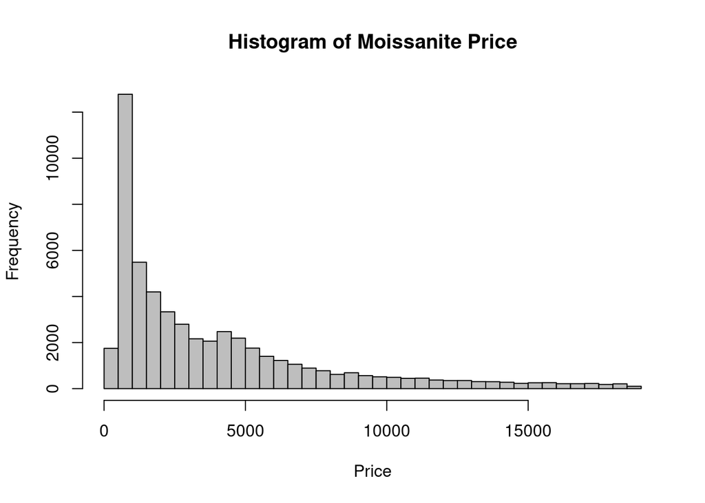

```r
hist(moissanite$price,
     breaks = 40,
     main = "Histogram of Moissanite Price",
     xlab = "Price",
     col = "gray")
```

# Exercise 2.7: Gamma GLM vs Full MLR

Model 1 is a Gamma GLM with log link using the same predictor set as the full MLR model:

`glm(price ~ ., data = train, family = Gamma(link = "log"))`

Model 2 is the full MLR model from Exercise 2.1:

`lm(price ~ ., data = train)`

AIC is computed from the model fitted on the training data. RMSE is computed on the original `price` scale. For the Gamma GLM, use `type = "response"` so predictions are returned on the price scale. For a prediction-focused recommendation, test RMSE should be the primary criterion; AIC is a likelihood-based in-sample model comparison criterion and may not always agree with test RMSE.

```r
# Numerical-stability step for the Gamma GLM:
# center and scale the continuous predictors using the training data only.
# This does not change the substantive predictor set; it only improves glm()
# convergence for the Gamma(log) fit.
numeric_predictors_q7 <- c("carat", "depth", "table", "x", "y", "z")

train_q7 <- train
test_q7  <- test

center_q7 <- sapply(train_q7[, numeric_predictors_q7], mean)
scale_q7  <- sapply(train_q7[, numeric_predictors_q7], sd)

train_q7_scaled <- train_q7
test_q7_scaled  <- test_q7

train_q7_scaled[, numeric_predictors_q7] <- as.data.frame(
  scale(train_q7[, numeric_predictors_q7], center = center_q7, scale = scale_q7)
)

test_q7_scaled[, numeric_predictors_q7] <- as.data.frame(
  scale(test_q7[, numeric_predictors_q7], center = center_q7, scale = scale_q7)
)

# Use a log-linear fit to provide stable starting values for Gamma(log).
log_start_q7 <- lm(log(price) ~ ., data = train_q7_scaled)
eta_start_q7 <- predict(log_start_q7, newdata = train_q7_scaled)
eta_start_q7 <- pmin(
  pmax(eta_start_q7, log(min(train_q7_scaled$price) / 10)),
  log(max(train_q7_scaled$price) * 10)
)

glm.gamma <- glm(price ~ ., data = train_q7_scaled,
                 family = Gamma(link = "log"),
                 etastart = eta_start_q7,
                 control = glm.control(maxit = 100, epsilon = 1e-8))

# Refit the full MLR on the same scaled training data used for Model 1.
# For linear regression, centering/scaling predictors does not change predictions;
# it simply keeps the comparison on the same design matrix as the Gamma GLM.
mlr.full.q7 <- lm(price ~ ., data = train_q7_scaled)

summary(glm.gamma)
```

```
##
## Call:
## glm(formula = price ~ ., family = Gamma(link = "log"), data = train_q7_scaled,
##     etastart = eta_start_q7, control = glm.control(maxit = 100,
##         epsilon = 1e-08))
##
## Coefficients:
##               Estimate Std. Error  t value Pr(>|t|)
## (Intercept)   7.098877   0.006751 1051.515   <2e-16 ***
## carat        -0.482100   0.004342 -111.041   <2e-16 ***
## cutGood       0.141542   0.005959   23.754   <2e-16 ***
## cutVery Good  0.180219   0.005710   31.562   <2e-16 ***
## cutPremium    0.160968   0.005713   28.176   <2e-16 ***
## cutIdeal      0.207956   0.005924   35.106   <2e-16 ***
## colorI        0.134662   0.004677   28.792   <2e-16 ***
## colorH        0.249736   0.004424   56.454   <2e-16 ***
## colorG        0.339799   0.004317   78.709   <2e-16 ***
## colorF        0.402219   0.004407   91.277   <2e-16 ***
## colorE        0.441022   0.004415   99.889   <2e-16 ***
## colorD        0.500264   0.004635  107.924   <2e-16 ***
## clarityVS     0.246449   0.001997  123.408   <2e-16 ***
## clarityVV     0.445256   0.002731  163.041   <2e-16 ***
## clarityIF     0.575510   0.005129  112.205   <2e-16 ***
## depth         0.067176   0.001138   59.049   <2e-16 ***
## table         0.018081   0.001154   15.662   <2e-16 ***
## x             1.375236   0.006511  211.217   <2e-16 ***
## y             0.032614   0.003728    8.748   <2e-16 ***
## z             0.149457   0.004001   37.353   <2e-16 ***
## ---
## Signif. codes:  0 '***' 0.001 '**' 0.01 '*' 0.05 '.' 0.1 ' ' 1
##
## (Dispersion parameter for Gamma family taken to be 0.02815717)
##
##     Null deviance: 36939.5  on 37745  degrees of freedom
## Residual deviance:   966.1  on 37726  degrees of freedom
## AIC: 556720
##
## Number of Fisher Scoring iterations: 45
```

```r
summary(mlr.full.q7)
```

```
##
## Call:
## lm(formula = price ~ ., data = train_q7_scaled)
##
## Residuals:
##      Min       1Q   Median       3Q      Max
## -23435.4   -605.1   -162.1    455.4  10829.0
##
## Coefficients:
##               Estimate Std. Error t value Pr(>|t|)
## (Intercept)    241.289     49.044   4.920 8.70e-07 ***
## carat         5245.746     31.540 166.318  < 2e-16 ***
## cutGood       1051.688     43.288  24.295  < 2e-16 ***
## cutVery Good  1231.450     41.482  29.687  < 2e-16 ***
## cutPremium    1217.719     41.502  29.341  < 2e-16 ***
## cutIdeal      1306.351     43.033  30.357  < 2e-16 ***
## colorI         881.489     33.977  25.944  < 2e-16 ***
## colorH        1334.413     32.137  41.523  < 2e-16 ***
## colorG        1815.841     31.362  57.899  < 2e-16 ***
## colorF        2001.317     32.012  62.518  < 2e-16 ***
## colorE        2064.926     32.074  64.379  < 2e-16 ***
## colorD        2264.136     33.674  67.237  < 2e-16 ***
## clarityVS     1172.910     14.508  80.848  < 2e-16 ***
## clarityVV     1708.114     19.839  86.097  < 2e-16 ***
## clarityIF     2042.627     37.261  54.819  < 2e-16 ***
## depth          -96.185      8.265 -11.638  < 2e-16 ***
## table          -62.312      8.386  -7.430 1.11e-13 ***
## x            -1159.367     47.300 -24.511  < 2e-16 ***
## y               42.119     27.082   1.555   0.1199
## z              -55.724     29.067  -1.917   0.0552 .
## ---
## Signif. codes:  0 '***' 0.001 '**' 0.01 '*' 0.05 '.' 0.1 ' ' 1
##
## Residual standard error: 1219 on 37726 degrees of freedom
## Multiple R-squared:  0.9058, Adjusted R-squared:  0.9058
## F-statistic: 1.91e+04 on 19 and 37726 DF,  p-value: < 2.2e-16
```

```r
# Predictions on original price scale.
glm.gamma.train.preds <- predict(glm.gamma, newdata = train_q7_scaled, type = "response")
glm.gamma.test.preds  <- predict(glm.gamma, newdata = test_q7_scaled, type = "response")

mlr.full.train.preds <- predict(mlr.full.q7, newdata = train_q7_scaled)
mlr.full.test.preds  <- predict(mlr.full.q7, newdata = test_q7_scaled)

model_1_2_table <- data.frame(
  Model = c("Model 1: Gamma GLM with log link", "Model 2: Full MLR"),
  Training_RMSE = c(
    rmse(train_q7_scaled$price, glm.gamma.train.preds),
    rmse(train_q7_scaled$price, mlr.full.train.preds)
  ),
  Test_RMSE = c(
    rmse(test_q7_scaled$price, glm.gamma.test.preds),
    rmse(test_q7_scaled$price, mlr.full.test.preds)
  ),
  AIC = c(
    AIC(glm.gamma),
    AIC(mlr.full.q7)
  )
)

model_1_2_table
```

| Model | Training_RMSE | Test_RMSE | AIC |
| --- | --- | --- | --- |
| Model 1: Gamma GLM with log link | 3752.793 | 1064.091 | 556719.6 |
| Model 2: Full MLR | 1218.690 | 1240.105 | 643571.3 |